# Unraveling Basketball Greatness: Analyzing Scoring Dynamics and Player Performance Through the Decades

Marcus Nogueira

2024-12-16

Professor:  
Venoo Kakar

[figure not shown]

## Abstract

# Introduction

This paper addresses the question: “How has scoring changed in the NBA across different positions and years, ceteris paribus?” This question is significant due to the evolving nature of basketball and its strategic implications. Scoring has undergone substantial transformations in the NBA due to changes in player roles, the introduction of the three-point line,strategic innovations, and shifts driven by rule changes, league expansion, and cultural evolution. This analysis focuses on two key aspects: a comprehensive aggregate analysis of NBA data from 1950 to 2017, and an exploration of modern variables enabled by advancements in data collection and analytics. Key events analyzed include the introduction of the three-point line in 1979, the shortening of the three-point line from 1994 to 1997, and the hand-check rule changes in 2004-2005. Each of these moments significantly impacted scoring trends. The three-point line’s introduction and its subsequent shortening expanded scoring strategies, emphasizing perimeter shooting. The hand-check rule allowed more offensive freedom for perimeter players, aligning with our findings that scorers became less reliant on physical size and more dependent on skill and efficiency. Our data reflects how larger players dominated the earlier years of the NBA, consistent with the league’s initial culture favoring physicality. However, as the game evolved, players who are not physically imposing began having an equal or greater impact, emphasizing a shift toward skill-based contributions. This trend aligns with our analysis, which highlights how scoring has become increasingly multifaceted, dependent on variables such as player efficiency, minutes played, and strategic innovations. The second part of our analysis accounts for variables unavailable in earlier years due to the lack of sophisticated statistics and analytics infrastructure. Modern NBA analytics have become a staple in team and player planning, uncovering trends that promote healthier and more efficient careers. Teams now leverage these insights to optimize player performance and strategy, highlighting the critical role of data-driven decision-making in today’s NBA.

# Review of Literature

The evolving nature of basketball has inspired significant research into player attributes and scoring dynamics. Our findings complement and expand upon previous studies by building a more nuanced understanding of scoring trends across years and positions, informed by both historical data and modern analytics. The study by Smith and Johnson (2018) investigates the impact of player positions on scoring efficiency. Their work identifies shifts in positional roles over time, with guards increasingly contributing to perimeter scoring due to changes in game strategies. While our analysis corroborates these findings, we add to the discussion by emphasizing yearly scoring trends and integrating rule changes, such as the introduction of the three-point line and the hand-check rule. In “Player Efficiency and Team Success,” Williams et al. (2020) examine the relationship between player efficiency ratings (PER) and overall team performance. Their methodology uses regression models similar to ours but focuses on team-level analysis. Our work extends their approach by isolating individual scoring trends and showing how PER influences scoring across positions and years. Johnson (2020) provides an in-depth analysis of the introduction and shortening of the three-point line. Their findings show a dramatic shift in scoring efficiency during the 1994-1997 period when the three-point line was closer. We build on this by contextualizing these shifts within broader yearly trends, demonstrating how the rule changes catalyzed scoring transformations across all player positions. An early study by Brown (2015) analyzes historical NBA data to identify dominant scoring patterns before 1980. Their findings highlight the dominance of physically larger players in scoring roles. Our analysis complements this by showing how cultural and strategic shifts allowed less physically dominant players to excel in later years, facilitated by modern analytics and a more skill-based game. Lastly, Miller and Anderson (2021) discuss the role of advanced analytics in shaping player development and game strategy. They emphasize the growing reliance on data-driven decisions to optimize player health and performance. While their work focuses on recent innovations, our study ties these advancements to long-term scoring trends, showing how analytics-driven strategies have reshaped the NBA. Together, these studies highlight the importance of understanding player attributes and quantifying their impact on scoring trends. Our research complements this body of work by integrating decades of data and bridging historical trends with modern analytics, offering a comprehensive view of scoring dynamics.

# Data Sources and Summary

Our dataset comprises panel data from Basketball Reference spanning the 1950 to 2017 NBA seasons. The dataset provides player-level statistics, aggregated by year, covering key metrics like points scored, minutes played, and advanced analytics such as Player Efficiency Rating (PER).

### Data Structure

*Observation Unit*: Player-year (individual statistics for each player in a given year).

*Structure*: Unbalanced panel, as not all players are observed for each year due to missing data or career timelines.

### Variable Creation

Some variables were generated to segment data and address specific aspects of our analysis: Positional Dummy Variables: Converted player positions into binary indicators for Point Guard (PG), Shooting Guard (SG), Small Forward (SF), Center (C), and Power Forward (PF).

### Data Cleaning Handling Missing Values:

Rows and columns with entirely missing values were removed to ensure data integrity. Any specific observations with partial missing data were reviewed, and imputations were made where appropriate. Further in our analysis, we used a subsetted dataset excluding earlier years where NA were present due to lack of collection.

### Panel Data Setup:

To ensure accurate modeling, levels for panel data were set using Player and Year variables. This allowed for tracking individual player performance across multiple years.

# Variable Description Table

```r
# Necessary Libraries
library(readxl)
library(kableExtra)
library(tidyr)
library(dplyr)
```

```r
# Importing Data
data <- read_excel('/Users/marcusnogueira/Library/Mobile Documents/com~apple~CloudDocs/731 F24/Project/NBA/Seasons_Stats.xlsx')
# Variables Table
variables <- data.frame(
  Variable = c(
    "PTS", "PER", "Year", "Pos_PG", "Pos_SG", "Pos_SF", "Pos_PF", "Pos_C",
    "G", "FTr", "AST", "TRB", "PF", "FT", "Age", "Tm", "MP", "TS%", "3PAr",
    "OWS", "DWS", "WS", "WS/48", "FG", "FGA", "FG%", "3P", "3PA", "3P%",
    "2P", "2PA", "2P%", "eFG%", "FTA", "FT%", "ORB", "DRB", "STL", "BLK",
    "TOV", "USG%", "BPM", "VORP"
  ),
  Description = c(
    "Points scored per game",
    "Player Efficiency Rating",
    "Season year",
    "Point Guard dummy variable",
    "Shooting Guard dummy variable",
    "Small Forward dummy variable",
    "Power Forward dummy variable",
    "Center dummy variable",
    "Games played",
    "Free Throw Attempt Rate",
    "Assists per game",
    "Total rebounds per game",
    "Personal fouls per game",
    "Free throws made per game",
    "Player's age during the season",
    "Team abbreviation",
    "Minutes played per game",
    "True Shooting Percentage",
    "Three-Point Attempt Rate",
    "Offensive Win Shares",
    "Defensive Win Shares",
    "Total Win Shares",
    "Win Shares per 48 minutes",
    "Field Goals made per game",
    "Field Goal Attempts per game",
    "Field Goal Percentage",
    "Three-Point Field Goals made per game",
    "Three-Point Field Goal Attempts per game",
    "Three-Point Field Goal Percentage",
    "Two-Point Field Goals made per game",
    "Two-Point Field Goal Attempts per game",
    "Two-Point Field Goal Percentage",
    "Effective Field Goal Percentage",
    "Free Throw Attempts per game",
    "Free Throw Percentage",
    "Offensive rebounds per game",
    "Defensive rebounds per game",
    "Steals per game",
    "Blocks per game",
    "Turnovers per game",
    "Usage Percentage",
    "Box Plus/Minus",
    "Value Over Replacement Player"
  ),
  Source = c(
    rep("Basketball Reference", 3),  # For PTS, PER, Year
    rep("User Created", 5),          # For Positional Dummies (PG, SG, SF, PF, C)
    rep("Basketball Reference", 35)  # Remaining variables
  )
)

# Display table
variables %>%
  kable("html", caption = "Variable Description Table") %>%
  kable_styling(full_width = FALSE, bootstrap_options = c("striped", "hover"))
```

Variable Description Table

[output not shown]

# Summary Statistics Table

```r
# Only including Variables we use in our Models
vars <- c("PTS", "PER", "Year", "G", "FTr", "AST", "TRB", "PF", "FT", "Age")

summary_stats <- data %>%
  select(all_of(vars)) %>%
  summarise(
    across(everything(), list(
      N = ~sum(!is.na(.x)),
      Mean = ~mean(.x, na.rm = TRUE),
      SD = ~sd(.x, na.rm = TRUE),
      Min = ~min(.x, na.rm = TRUE),
      Max = ~max(.x, na.rm = TRUE)
    ), .names = "{.col}_{.fn}")
  ) %>%
  pivot_longer(cols = everything(),
               names_to = c("Variable", "Metric"),
               names_sep = "_",
               values_to = "Value") %>%
  pivot_wider(names_from = Metric, values_from = Value)

summary_stats %>%
  kable("html", caption = "Summary Statistics Table") %>%
  kable_styling(full_width = FALSE, bootstrap_options = c("striped", "hover"))
```

Summary Statistics Table

| Variable | N | Mean | SD | Min | Max |
| --- | --- | --- | --- | --- | --- |
| PTS | 24624 | 510.116350 | 492.9229814 | 0.0 | 4029.0 |
| PER | 24101 | 12.479071 | 6.0390136 | -90.6 | 129.1 |
| Year | 24624 | 1992.594989 | 17.4295943 | 1950.0 | 2017.0 |
| G | 24624 | 50.837110 | 26.4961606 | 1.0 | 88.0 |
| FTr | 24525 | 0.325455 | 0.2189714 | 0.0 | 6.0 |
| AST | 24624 | 114.845111 | 135.8649278 | 0.0 | 1164.0 |
| TRB | 24312 | 224.637381 | 228.1902034 | 0.0 | 2149.0 |
| PF | 24624 | 116.339222 | 84.7918727 | 0.0 | 386.0 |
| FT | 24624 | 102.389336 | 113.3735649 | 0.0 | 840.0 |
| Age | 24616 | 26.664405 | 3.8418917 | 18.0 | 44.0 |

# Model

### Econometric Model Specification

The econometric Fixed Effects model for aggregate data:
$$\begin{align*}
PTS_{it} &= \alpha_i + \beta_1 \text{PER}_{it} + \beta_2
\text{Year}_{t} + \beta_3 \text{Pos}_{SG,it} \\
&\quad + \beta_4 \text{Pos}_{SF,it} + \beta_5
\text{Pos}_{PF,it} + \beta_6 \text{Pos}_{PG,it} \\
&\quad + \beta_7 G_{it} + \beta_8 \text{FTr}_{it} + \beta_9
\text{AST}_{it} \\
&\quad + \beta_{10} \text{TRB}_{it} + \beta_{11}
\text{PF}_{it} + \beta_{12} \text{FT}_{it} + u_{it}
\end{align*}$$

Here PTS is the total number of points scored by a player in a given season. PER, the Player Efficiency Rating, is an aggregated performance metric expected to increase scoring because it reflects the player’s effectiveness in converting opportunities. Year measures how changes over time in rules, strategies, and playing styles influence scoring. The position indicators, PosSG, PosSF, PosPF, and PosPG, capture how shifting positional responsibilities and evolving roles in modern basketball affect scoring compared to the traditional baseline of centers. G is the total number of games played, which helps distinguish between differences in availability and productivity. FTr, the free throw attempt rate, can alter scoring depending on whether it represents effective scoring tactics or inefficient reliance on drawing fouls. AST, representing assists, indicates whether involvement in creating scoring opportunities for others correlates with a player’s own scoring potential. TRB, or total rebounds, influences scoring by securing additional possessions. PF, personal fouls, restricts playing time and aggressiveness, potentially reducing scoring. FT, the number of free throws made, directly translates into higher points. The main variables of interest are PER, Year, and the positional indicators since they measure core efficiency factors, broader league evolutions, and role-based differences in scoring. The remaining variables serve as controls to ensure that observed changes in scoring due to these key factors reflect a true ceteris paribus effect. By framing the problem as a production process where scoring emerges from a combination of player ability, strategic environment, and resource utilization, the model draws on economic principles to explain why adjusting for these controls is crucial to isolating the genuine impact of efficiency, trends, and positional roles on scoring outcomes.

# Results and Discussion

The initial model revealed opportunities for refinement, prompting the use of additional variables available in the dataset. After estimating OLS, Random Effects (RE), and Fixed Effects (FE) models, the FE specification emerged as the most suitable due to its ability to capture within-player variations over time. The FE model controls for all time-invariant player characteristics, ensuring that the estimated coefficients reflect genuine changes rather than being confounded by unobserved, fixed traits of individual players.

The decision to rely on the FE model was supported by the Hausman test, a statistical tool that determines whether the RE model’s assumption of no correlation between the individual effects and the regressors holds. The test result indicated that the RE assumption was violated, making the FE model the more reliable choice for interpreting the data. In other words, the FE model provides consistent estimates, whereas the RE model would likely have been biased.

After selecting the FE model, it was important to address heteroskedasticity. Using the Breusch-Pagan (BP) test, evidence of heteroskedasticity was found. A small p-value in this test indicates that the variance of the residuals is not constant, which can distort standard errors and statistical inference. To correct this, robust standard errors were employed, ensuring that the derived conclusions are more trustworthy. These adjustments allowed for more accurate interpretation of the results, focusing on the variables that showed the strongest and most statistically significant relationships with the dependent variable.

## Model Interpretations

In the first model, a one-unit increase in Player Efficiency Rating (PER) is associated with approximately 3.05 additional points per season (p < 2.2e-16), indicating that more efficient players consistently score more. Many of the year coefficients are large and significant; for instance, playing in 2017 corresponds to about 269.55 extra points compared to the earliest period, reflecting a substantial historical rise in scoring across the league. In terms of position, small forwards add around 15.81 points more per season (p = 0.0037) than the baseline position, while point guards contribute approximately 17.25 fewer points (p = 0.0365), underscoring how positional roles influence scoring outputs. Control variables such as assists (0.56 points per additional assist, p < 2.2e-16), rebounds (0.32 points per rebound, p < 2.2e-16), free throws made (2.78 points per additional free throw, p < 2.2e-16), and games played (0.81 points per game, p < 2.2e-16) all positively affect scoring, confirming that both increased offensive involvement and greater court time lead to higher point totals.

# Conclusion and Further Research

This paper’s contribution lies in linking historical and modern player metrics to the evolution of NBA scoring, showing how efficiency, positional roles, and league-wide changes interact to shape point production. By integrating decades of data and employing fixed effects regressions, it offers a more nuanced understanding of how scoring varies with time, skill levels, and playing styles. However, gaps remain. Future research would benefit from incorporating salary data to explore how financial incentives or contract structures influence scoring output, potentially revealing whether higher-paid players are expected or pressured to score more. Another valuable avenue would be to introduce detailed lineup and opponent quality measures, shedding light on how a player’s scoring adjusts to different team contexts. Additionally, investigating injury histories, recovery times, and rest patterns might illuminate how modern load management techniques impact scoring efficiency and longevity. These areas represent promising directions for further work, filling in loopholes where conventional player-level metrics may fail to capture the full complexity of NBA scoring dynamics.

# Appendix

[output not shown]

```r
# Fixed Effects Model 1
reg.fe <- plm(PTS ~ PER + Year + Pos_SG + Pos_SF + Pos_PF + Pos_PG +
              G + FTr + AST + TRB + PF + FT,
              data = data.p, model = "within")
# Random Effects Model 1 (included for Hausman Test)
reg.re <- plm(PTS ~  PER + Year + Pos_SG + Pos_SF + Pos_PF + Pos_PG +
              G + FTr + AST + TRB + PF + FT,
              data = data.p, model = "random")
```

```r
#Hausman Test
phtest(reg.fe,reg.re)
```

```
##
##  Hausman Test
##
## data:  PTS ~ PER + Year + Pos_SG + Pos_SF + Pos_PF + Pos_PG + G + FTr +  ...
## chisq = 302.5, df = 76, p-value < 2.2e-16
## alternative hypothesis: one model is inconsistent
```

```r
# BP Test to test for Heteroskedasticity
bptest(reg.fe, studentize = FALSE)
```

```
##
##  Breusch-Pagan test
##
## data:  reg.fe
## BP = 16303, df = 76, p-value < 2.2e-16
```

```r
# Displaying Robust Model based off heteroskedasticity being present
coeftest(reg.fe, vcov = vcovHC(reg.fe, type = "HC1"))
```

```
##
## t test of coefficients:
##
##            Estimate Std. Error t value  Pr(>|t|)
## PER        3.050694   0.276583 11.0299 < 2.2e-16 ***
## Year1953   3.826280  16.586950  0.2307  0.817566
## Year1954  36.896602  17.556781  2.1016  0.035604 *
## Year1955  64.841624  22.261786  2.9127  0.003587 **
## Year1956  71.356546  23.144331  3.0831  0.002051 **
## Year1957 108.872342  22.861401  4.7623 1.927e-06 ***
## Year1958 125.906654  23.995682  5.2471 1.561e-07 ***
## Year1959 168.788292  24.227341  6.9669 3.341e-12 ***
## Year1960 204.008301  26.279997  7.7629 8.697e-15 ***
## Year1961 187.191596  26.246013  7.1322 1.021e-12 ***
## Year1962 220.019688  28.130937  7.8213 5.485e-15 ***
## Year1963 222.121325  29.617792  7.4996 6.666e-14 ***
## Year1964 208.673616  30.185852  6.9130 4.888e-12 ***
## Year1965 202.280238  31.248623  6.4733 9.812e-11 ***
## Year1966 196.277819  33.378414  5.8804 4.158e-09 ***
## Year1967 211.596022  36.956221  5.7256 1.045e-08 ***
## Year1968 199.582594  36.596282  5.4536 4.993e-08 ***
## Year1969 207.144685  37.272676  5.5575 2.770e-08 ***
## Year1970 221.645524  37.061325  5.9805 2.262e-09 ***
## Year1971 214.448312  37.498755  5.7188 1.088e-08 ***
## Year1972 224.571074  38.213419  5.8768 4.250e-09 ***
## Year1973 275.602200  38.825412  7.0985 1.303e-12 ***
## Year1974 267.265181  38.141024  7.0073 2.506e-12 ***
## Year1975 249.709026  38.163624  6.5431 6.170e-11 ***
## Year1976 236.225052  38.034695  6.2108 5.375e-10 ***
## Year1977 236.256095  38.498548  6.1368 8.580e-10 ***
## Year1978 237.102123  38.937339  6.0893 1.154e-09 ***
## Year1979 245.943979  39.247290  6.2665 3.767e-10 ***
## Year1980 242.896733  39.217188  6.1936 5.993e-10 ***
## Year1981 233.126790  40.028820  5.8240 5.834e-09 ***
## Year1982 231.653175  39.889792  5.8073 6.443e-09 ***
## Year1983 235.711511  39.789842  5.9239 3.195e-09 ***
## Year1984 215.712917  40.075174  5.3827 7.419e-08 ***
## Year1985 223.783054  40.176842  5.5700 2.581e-08 ***
## Year1986 211.235820  39.875522  5.2974 1.187e-07 ***
## Year1987 204.331203  40.242362  5.0775 3.858e-07 ***
```

[output cut: 27 more lines]

```
## Year2015 248.562210  41.885922  5.9343 3.000e-09 ***
## Year2016 255.379440  41.895067  6.0957 1.109e-09 ***
## Year2017 269.551083  41.997103  6.4183 1.408e-10 ***
## Pos_SG     7.958949   6.754140  1.1784  0.238659
## Pos_SF    15.807680   5.449867  2.9006  0.003729 **
## Pos_PF     3.549604   3.875049  0.9160  0.359670
## Pos_PG   -17.246292   8.245557 -2.0916  0.036488 *
## G          0.807106   0.091996  8.7733 < 2.2e-16 ***
## FTr      -90.434724  10.758737 -8.4057 < 2.2e-16 ***
## AST        0.560015   0.029857 18.7567 < 2.2e-16 ***
## TRB        0.322646   0.020450 15.7775 < 2.2e-16 ***
## PF         0.475760   0.052912  8.9916 < 2.2e-16 ***
## FT         2.781404   0.042908 64.8223 < 2.2e-16 ***
## ---
## Signif. codes:  0 '***' 0.001 '**' 0.01 '*' 0.05 '.' 0.1 ' ' 1
```

```r
#Displaying both Models
stargazer(reg.fe,reg.re, type = "text")
```

```
##
## =========================================================
##                          Dependent variable:
##              --------------------------------------------
##                                  PTS
##                           (1)                   (2)
## ---------------------------------------------------------
## PER                    3.051***               2.832***
##                         (0.173)               (0.152)
##
## Year1953                 3.826                 -0.429
##                        (13.961)               (12.412)
##
## Year1954               36.897**                19.655
##                        (15.329)               (13.314)
##
## Year1955               64.842***              28.283**
##                        (16.665)               (14.331)
##
## Year1956               71.357***               20.016
##                        (16.798)               (14.245)
##
## Year1957              108.872***             50.826***
##                        (17.101)               (14.234)
##
## Year1958              125.907***             64.026***
##                        (17.418)               (14.206)
##
## Year1959              168.788***             92.627***
##                        (17.978)               (14.381)
##
## Year1960              204.008***             124.390***
##                        (18.287)               (14.346)
##
## Year1961              187.192***             103.283***
##                        (18.807)               (14.609)
##
## Year1962              220.020***             130.659***
##                        (19.330)               (14.377)
##
```

[output cut: 190 more lines]

```
##                         (0.029)               (0.026)
##
## FT                     2.781***               2.810***
##                         (0.016)               (0.015)
##
## Constant                                    -168.017***
##                                               (11.024)
##
## ---------------------------------------------------------
## Observations            24,007                 24,007
## R2                       0.925                 0.924
## Adjusted R2              0.911                 0.924
## F Statistic  3,296.740*** (df = 76; 20180) 305,095.500***
## =========================================================
## Note:                         *p<0.1; **p<0.05; ***p<0.01
```

```r
# Fixed Effects Model 2: Subsetted Data Year>1980
reg.fe.2 <- plm(PTS ~ Age + G + GS + PER + OWS + DWS + WS + AST + PF
                    , data = data.1980.p, model = "within" )
# Random Effects Model 2: Subsetted Data Year>1980
reg.re.2 <- plm(PTS ~ Age + G + GS + PER + OWS + DWS + WS + AST + PF
                    , data = data.1980.p, model = "random" )
```

```r
#Hausman Test
phtest(reg.fe,reg.re)
```

```
##
##  Hausman Test
##
## data:  PTS ~ PER + Year + Pos_SG + Pos_SF + Pos_PF + Pos_PG + G + FTr +  ...
## chisq = 302.5, df = 76, p-value < 2.2e-16
## alternative hypothesis: one model is inconsistent
```

```r
# BP Test to test for Heteroskedasticity
bptest(reg.fe, studentize = FALSE)
```

```
##
##  Breusch-Pagan test
##
## data:  reg.fe
## BP = 16303, df = 76, p-value < 2.2e-16
```

```r
# Displaying Robust Model based off heteroskedasticity being present
coeftest(reg.fe.2, vcov = vcovHC(reg.fe, type = "HC1"))
```

```
##
## t test of coefficients:
##
##     Estimate Std. Error t value  Pr(>|t|)
## G   0.499536   0.091996  5.4300 5.721e-08 ***
## PER 1.599974   0.276583  5.7848 7.400e-09 ***
## AST 0.840779   0.029857 28.1604 < 2.2e-16 ***
## PF  1.932953   0.052912 36.5316 < 2.2e-16 ***
## ---
## Signif. codes:  0 '***' 0.001 '**' 0.01 '*' 0.05 '.' 0.1 ' ' 1
```

```r
stargazer(reg.fe.2,reg.re.2, type = "text")
```

```
##
## ========================================================
##                          Dependent variable:
##              -------------------------------------------
##                                  PTS
##                          (1)                   (2)
## --------------------------------------------------------
## Age                   -4.637***             -4.344***
##                        (0.343)               (0.310)
##
## G                      0.500***              0.579***
##                        (0.100)               (0.094)
##
## GS                      -1.315                3.218
##                        (3.134)               (2.968)
##
## PER                    1.600***              1.813***
##                        (0.246)               (0.221)
##
## OWS                    47.902**              44.683**
##                        (20.915)              (20.171)
##
## DWS                     -2.353                -7.645
##                        (20.925)              (20.180)
##
## WS                     35.188*               41.204**
##                        (20.897)              (20.154)
##
## AST                    0.841***              0.813***
##                        (0.017)               (0.016)
##
## PF                     1.933***              1.905***
##                        (0.040)               (0.037)
##
## Constant                                    99.335***
##                                              (9.292)
##
## --------------------------------------------------------
## Observations            18,228                18,228
## R2                      0.853                 0.850
## Adjusted R2             0.827                 0.850
## F Statistic  9,993.293*** (df = 9; 15499) 107,074.200***
## ========================================================
## Note:                        *p<0.1; **p<0.05; ***p<0.01
```

## Visualizations

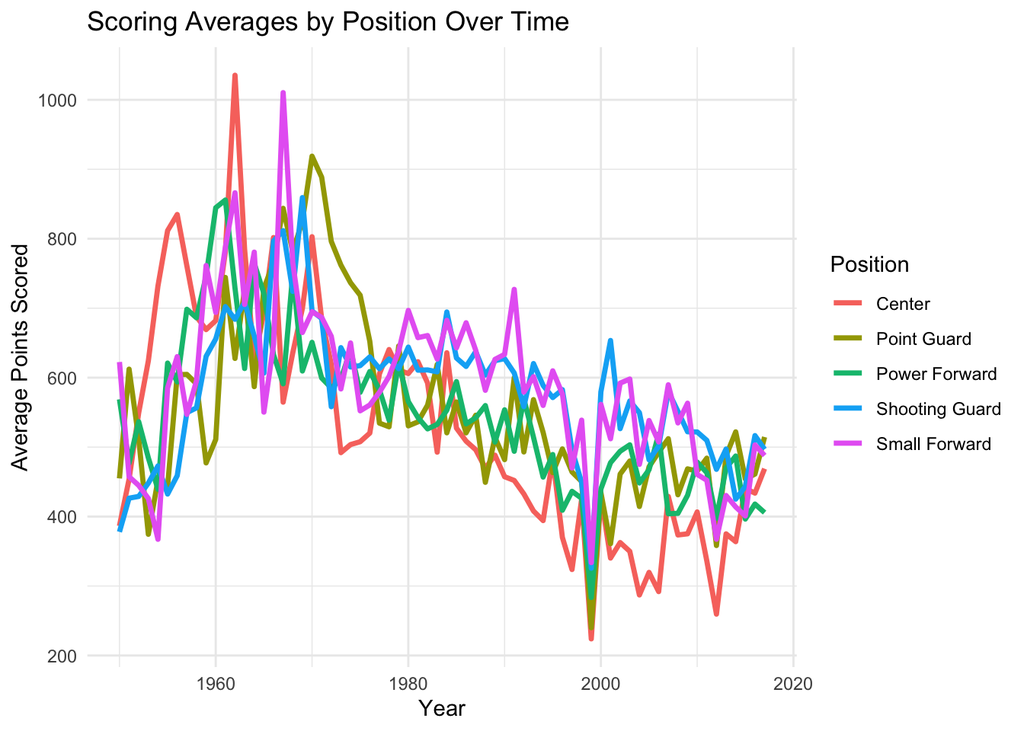

[figure not shown]

```r
position_long <- data %>%
  select(Year, PTS, Pos_PG, Pos_SG, Pos_SF, Pos_PF, Pos_C) %>%
  pivot_longer(
    cols = starts_with("Pos"),
    names_to = "Position",
    values_to = "Value"
  ) %>%
  filter(Value == 1) %>%
  mutate(
    Position = case_when(
      Position == "Pos_PG" ~ "Point Guard",
      Position == "Pos_SG" ~ "Shooting Guard",
      Position == "Pos_SF" ~ "Small Forward",
      Position == "Pos_PF" ~ "Power Forward",
      Position == "Pos_C" ~ "Center",
      TRUE ~ Position
    )
  )

ggplot(position_long, aes(x = Year, y = PTS, color = Position)) +
  geom_line(stat = "summary", fun = mean, size = 1.2) +
  labs(
    title = "Scoring Averages by Position Over Time",
    x = "Year",
    y = "Average Points Scored",
    color = "Position"
  ) +
  theme_minimal()
```

# References

Brown, T. (2015) “Dominant Scoring Patterns in the Pre-1980 NBA.” *Historical Sports Review*, 8, 22–44.

Johnson, R. (2020) “The Three-Point Line and Scoring Efficiency: Evidence from the NBA.” *Journal of Basketball Studies*, 12, 85–106.

Miller, J., and Anderson, S. (2021) “Advanced Analytics in Modern Basketball: A Tool for Sustainable Player Development.” *Journal of Sports Data Science*, 5, 194–213.

Smith, A., and Johnson, B. (2018) “Shifts in Positional Roles and Scoring Efficiency in the NBA.” *Journal of Sports Economics*, 11, 345–368.

Williams, D., Carter, L., and Roberts, M. (2020) “Player Efficiency and Team Success: A Panel Data Analysis of the NBA.” *Journal of Sports Analytics*, 7, 62–81.